# NISCOPS 2022 MONTHLY TRACKER ANALYSIS

Author

Nathaniel Amoh Boateng

# 1 Interviews Trend

## 1.1 Number of interviews per month per district per month

Graph of interviews done per month

Number of interviews per month.

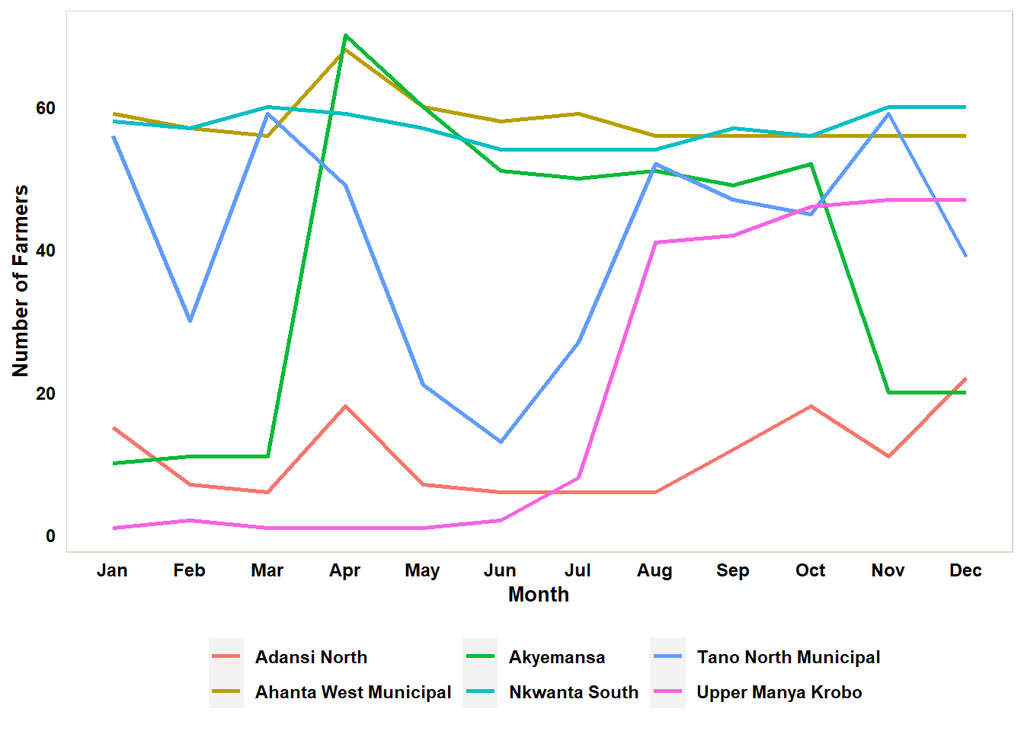

Table interviews done per month

Number of Interviews Per Month Per District

| District | Jan | Feb | Mar | Apr | May | Jun | Jul | Aug | Sep | Oct | Nov | Dec |
| --- | --- | --- | --- | --- | --- | --- | --- | --- | --- | --- | --- | --- |
| Adansi North | 15 | 7 | 6 | 18 | 7 | 6 | 6 | 6 | 12 | 18 | 11 | 22 |
| Ahanta West Municipal | 59 | 57 | 56 | 68 | 60 | 58 | 59 | 56 | 56 | 56 | 56 | 56 |
| Akyemansa | 10 | 11 | 11 | 70 | 60 | 51 | 50 | 51 | 49 | 52 | 20 | 20 |
| Nkwanta South | 58 | 57 | 60 | 59 | 57 | 54 | 54 | 54 | 57 | 56 | 60 | 60 |
| Tano North Municipal | 56 | 30 | 59 | 49 | 21 | 13 | 27 | 52 | 47 | 45 | 59 | 39 |
| Upper Manya Krobo | 1 | 2 | 1 | 1 | 1 | 2 | 8 | 41 | 42 | 46 | 47 | 47 |

## 1.2 Number of duplicated Observation to be deleted

Number of Duplicated Interviews Per Month Per District

| District | Jan | Feb | Mar | Apr | May | Jun | Jul | Aug | Sep | Oct | Nov | Dec |
| --- | --- | --- | --- | --- | --- | --- | --- | --- | --- | --- | --- | --- |
| Adansi North | 4 | NA | NA | 8 | NA | 2 | NA | NA | 2 | 4 | 9 | 6 |
| Ahanta West Municipal | 4 | 2 | NA | 16 | 6 | 3 | 7 | 2 | 2 | 2 | 3 | 2 |
| Akyemansa | NA | NA | NA | 17 | 5 | 4 | 2 | NA | 2 | 4 | NA | NA |
| Nkwanta South | 2 | 2 | 4 | 4 | 2 | 2 | NA | 2 | 4 | 2 | 2 | 2 |
| Tano North Municipal | 2 | 2 | 6 | 7 | NA | 2 | NA | 4 | 6 | 6 | 6 | NA |
| Upper Manya Krobo | NA | NA | NA | NA | NA | NA | NA | 6 | 4 | 4 | 4 | 4 |

## 1.3 Data used for analysis

The table below shows the number of farmers used for the analysis. The data drops duplicated observation as well as districts in which not adequate data were captured. Also the data focused on farmers who had been visited **at least 5 times** within the year under review.

Number of Interviews Per Month Per District

| District | Jan | Feb | Mar | Apr | May | Jun | Jul | Aug | Sep | Oct | Nov | Dec |
| --- | --- | --- | --- | --- | --- | --- | --- | --- | --- | --- | --- | --- |
| Ahanta West Municipal | 47 | 47 | 47 | 47 | 47 | 47 | 46 | 46 | 44 | 43 | 42 | 43 |
| Nkwanta South | 47 | 46 | 48 | 47 | 46 | 43 | 44 | 43 | 45 | 45 | 48 | 48 |
| Tano North Municipal | 51 | 27 | 54 | 44 | 21 | 11 | 26 | 48 | 43 | 41 | 54 | 37 |

In all a total of 152 unique farmers were interviewed from January 2022 to December 2022. This consists of 117 males and 35 females

The graph below explains the number of times farmers were interviewed

Number of times farmers were interviewed.

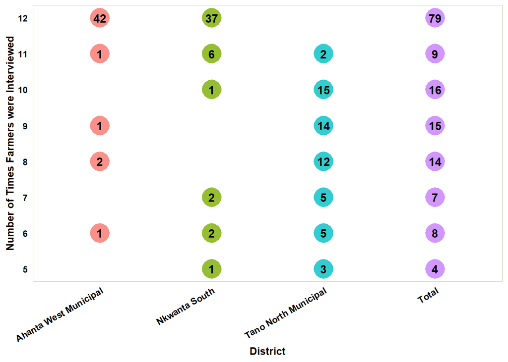

# 2 Training

## 2.1 Score for BMP Training Provided by Solidaridad

All farmers included in this tracking are farmers who have been trained by Solidaridad. At the first visit, the farmers were asked to rate the training provided by Solidaridad.

Ratings of Training by Farmers.

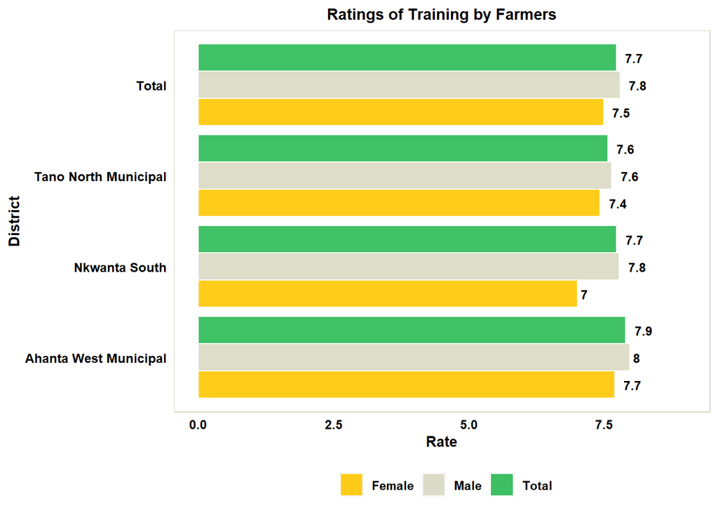

Reasons provided by farmers for the rating is indicated in the word cloud below

Reasons for Ratings Training by Farmers.

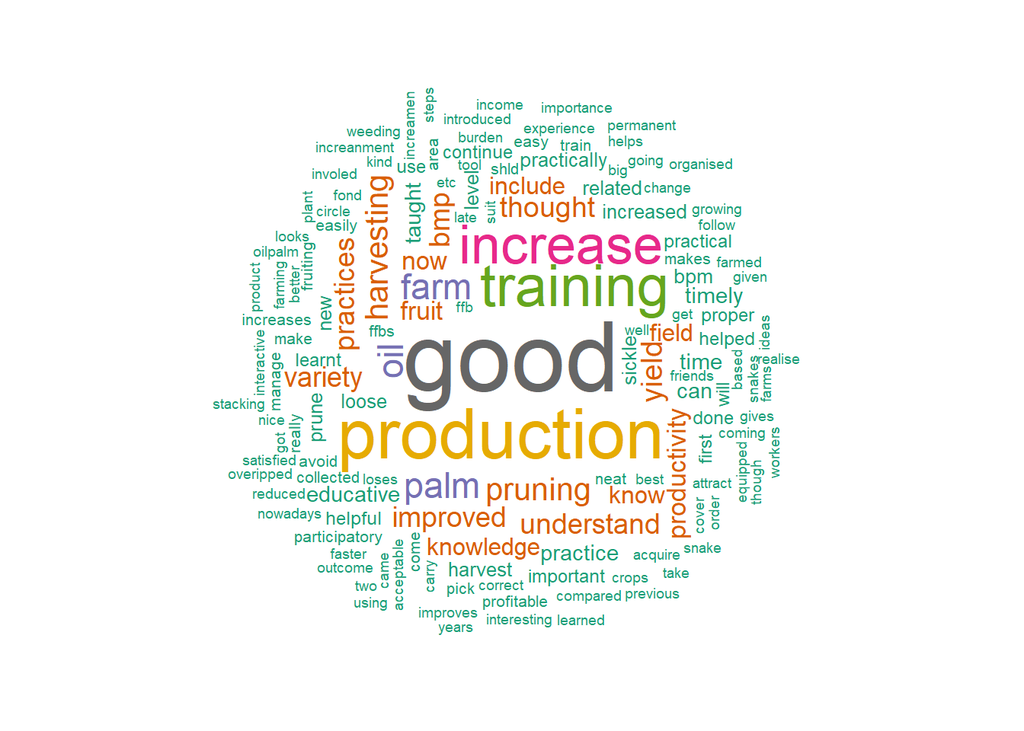

## 2.2 Other Training Over the Period

There is generally little training available for farmers to improve their business and farm practices.

Other Trainings Received by Farmers.

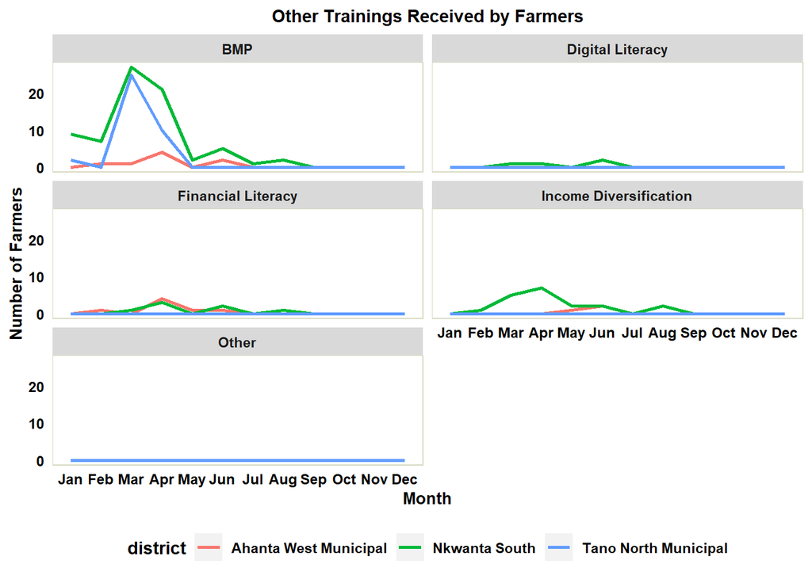

# 3 Farm Characteristics

## 3.1 Tree Varieties

Usually farmers have more than one farm. The AEAs are tasked to gather data for specific farms, one that the farmers is really enthusiastic about. On the first visit to the farmers, the size of the farm as well as the oil palm variety on the farms are captured.

Varieties of Oil Palm Planted.

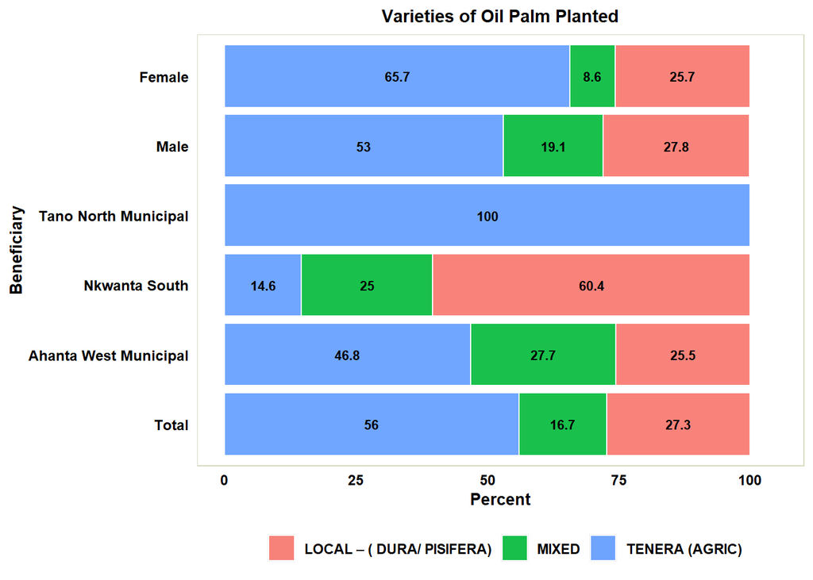

## 3.2 Farm Sizes

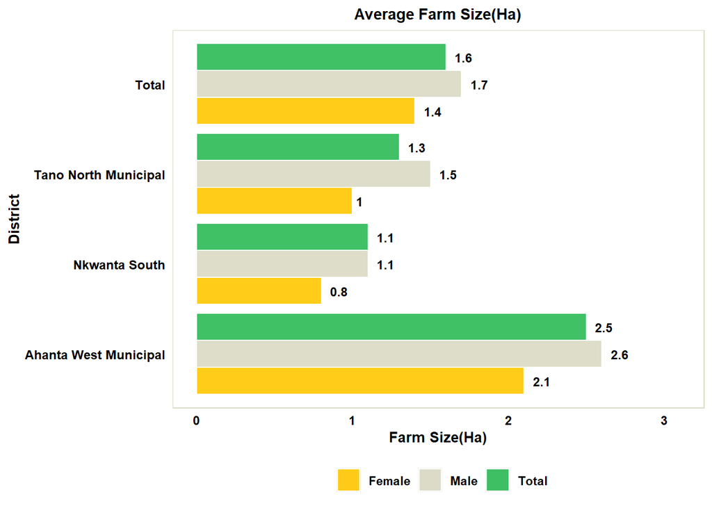

The farm sizes are categorized as less than 1 Ha, 1 to 3 Ha and greater than 3 Ha.

Percent of Beneficiaries and Farm Sizes.

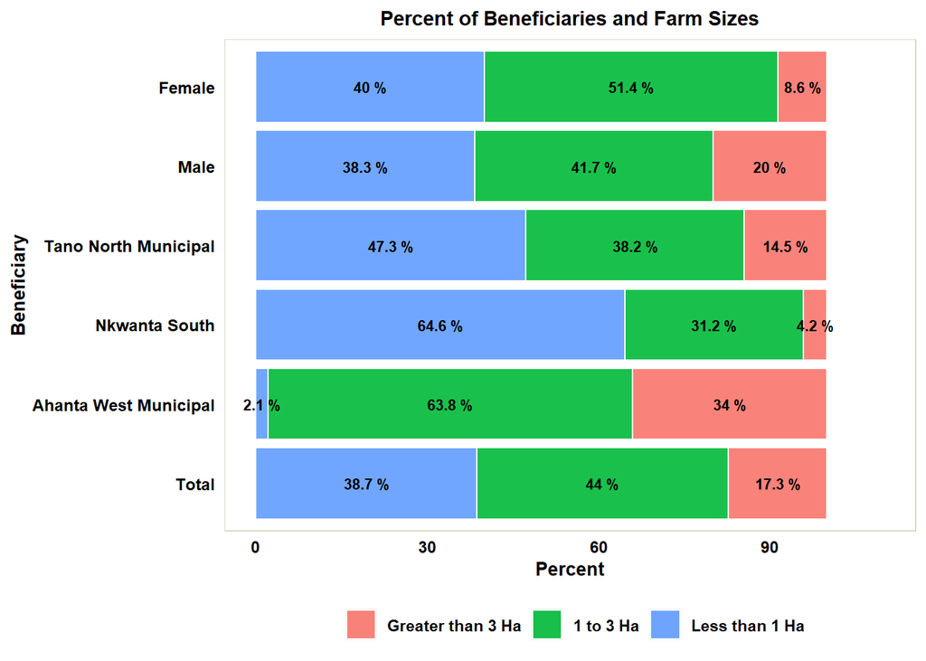

# 4 Farm Practices

## 4.1 Best Management Practices

Farmers were trained to conduct relevant best management practices. These practices are time bound and conducted within specific months. Below is a table showing the various BMPs and the number of farmers implementing them in the monitoring months.

No. of Farmers Implementing BMP Per Month

| Activities | Jan | Feb | Mar | Apr | May | Jun | Jul | Aug | Sep | Oct | Nov | Dec |
| --- | --- | --- | --- | --- | --- | --- | --- | --- | --- | --- | --- | --- |
| Palm Circle | 14 | 23 | 11 | 8 | 10 | 2 | 7 | 3 | 10 | 6 | 18 | 7 |
| Field Path | 5 | 10 | 15 | 19 | 12 | 8 | 4 | 7 | 11 | 10 | 11 | 1 |
| Weeding | 50 | 16 | 52 | 28 | 9 | 13 | 25 | 25 | 18 | 18 | 28 | 16 |
| Prunning | 41 | 24 | 25 | 28 | 4 | 7 | 15 | 7 | 15 | 7 | 15 | 6 |
| Box Frond Stacking | 6 | 1 | 9 | 19 | 9 | 2 | 9 | 5 | 4 | 2 | 2 | 2 |
| Leguminous Crop | 0 | 0 | 0 | 0 | 0 | 0 | 0 | 0 | 0 | 0 | 0 | 0 |
| Regular Harvests | 145 | 120 | 145 | 138 | 114 | 24 | 116 | 137 | 21 | 129 | 144 | 115 |

The number of farmers in the districts who implemented the various BMP activities at least once in any of the reviewing months is shown in the graph below.

Percent of Farmers Implementing Various Practices.

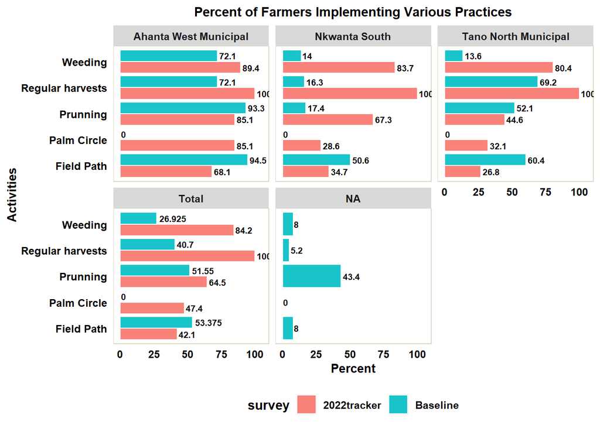

The graph below further assesses the changes in the percent of farmers implementing the various BMPs per district.

Percent changes for BMP application.

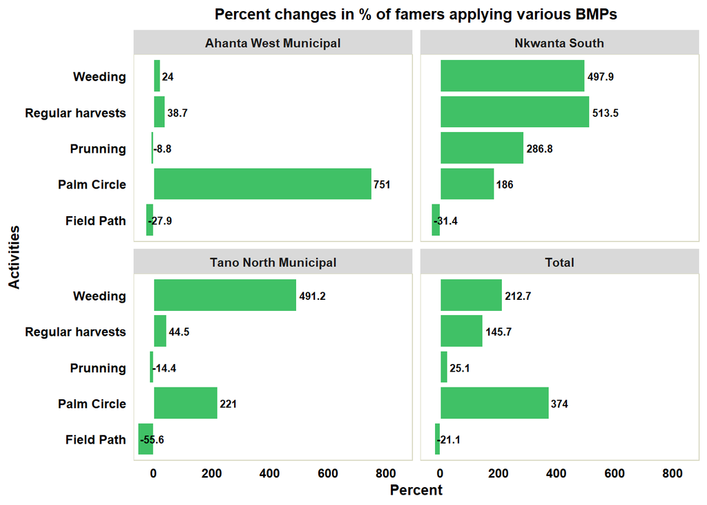

The graph below summarizes the number of BMP out of the 5 activities implemented by the farmers over the period. Farmers implemented an average of 3 activities ranging from 1 to 5

Average number of BMP activities by farmers.

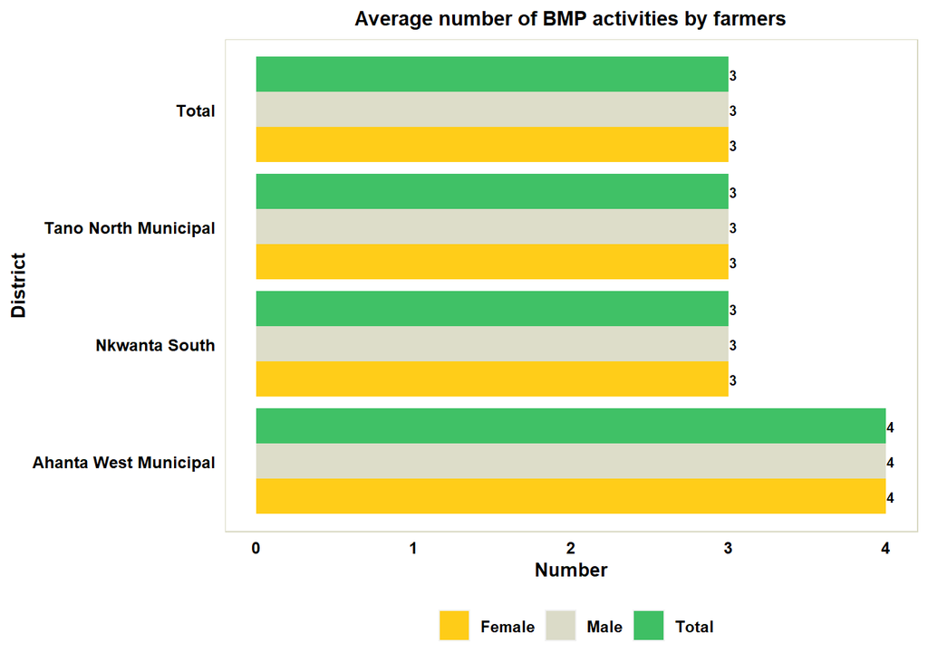

The three critical BMP for improved yields are path cleaning, palm circle weeding and harvesting at least twice a month. Farmers who have done a combination of these three in the year are assessed.

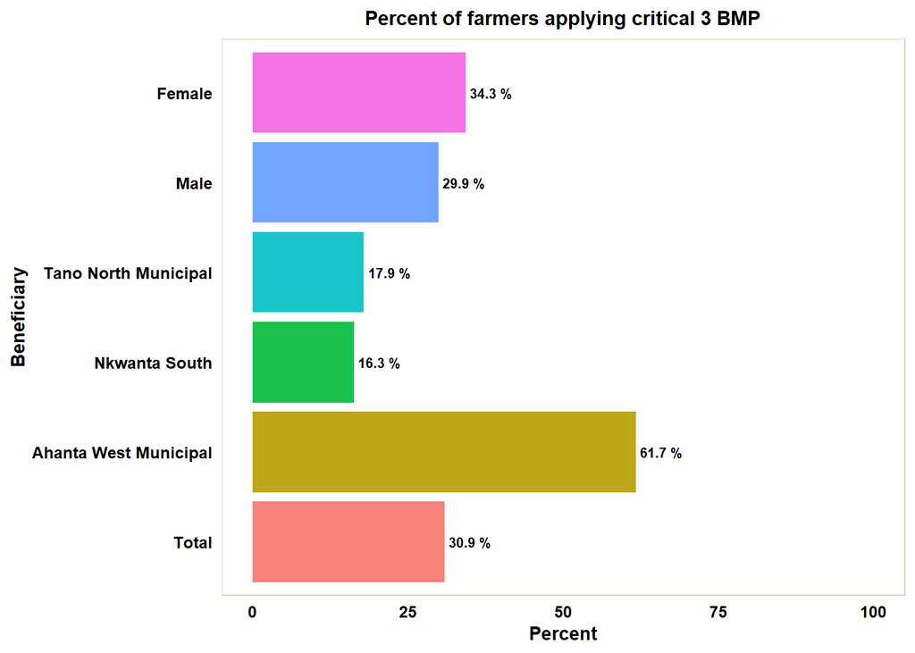

## 4.2 Labour Use

The average number of times different types of labour is engaged for farming activities is shown in the graph below.

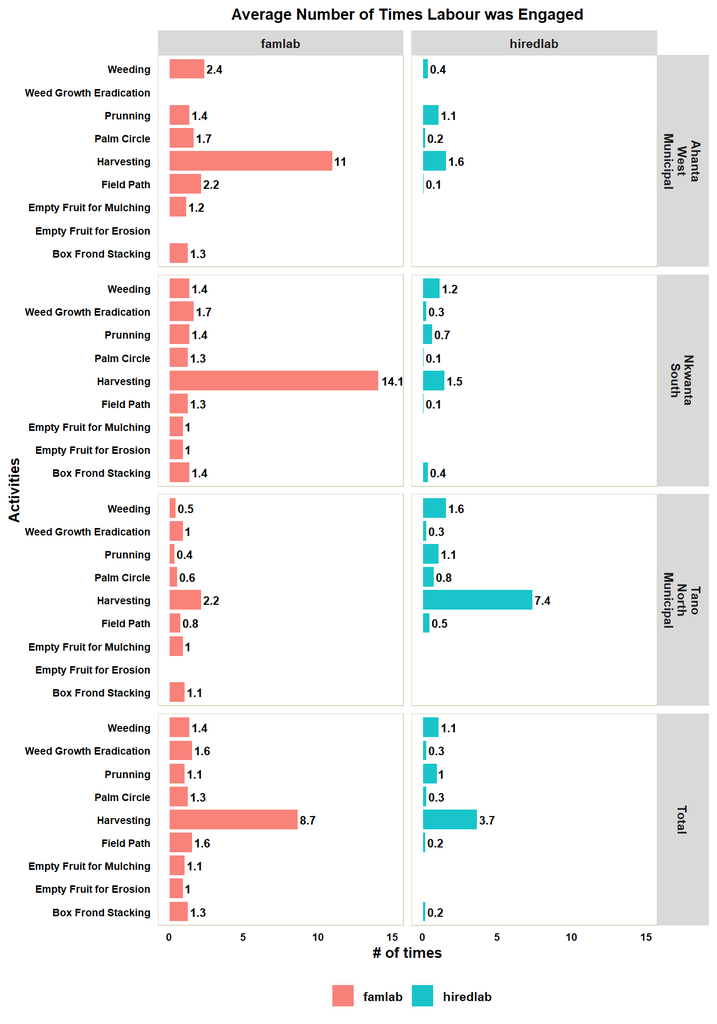

The graph below illustrates the number of persons who on the average are engaged for the different activities

Average Number of persons engaged for Activites.

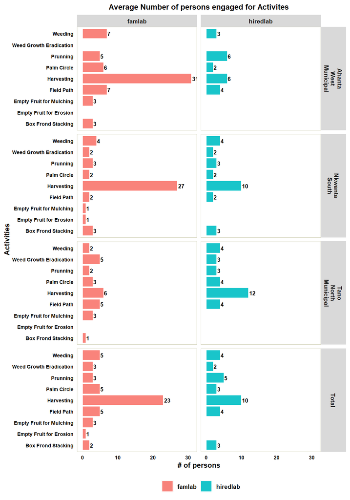

## 4.3 Labour Costs

For the few farmers who hire labour to apply the BMP, below is a summary of the cost of labour per activities

Avg Cost per Activites.

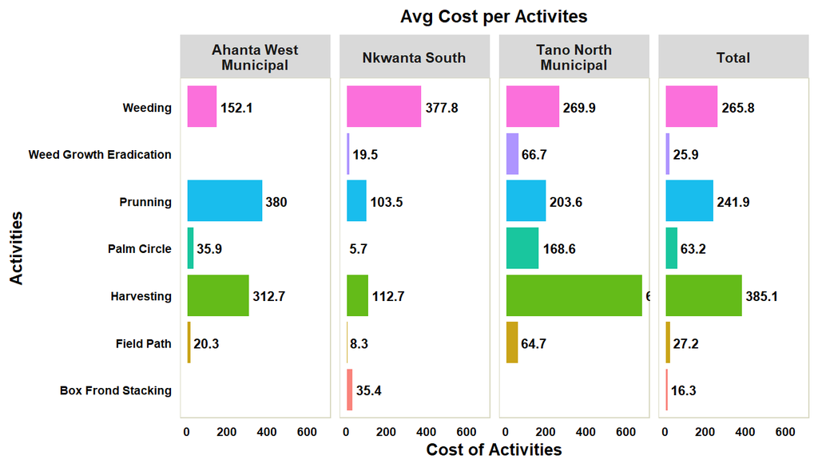

The overall labour cost is presented in the graph below

Avg Total Labour cost per Activites.

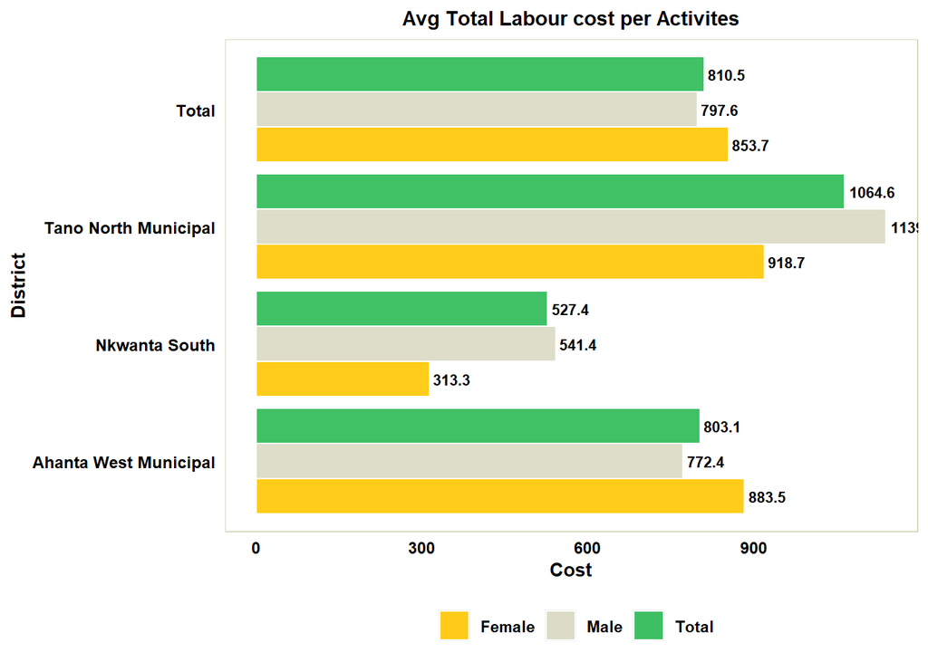

## 4.4 Input Use

In the graph below we see the proportion of farmers who ever applied the different kinds of inputs within the monitoring period

Percent of Farmers Using Inputs.

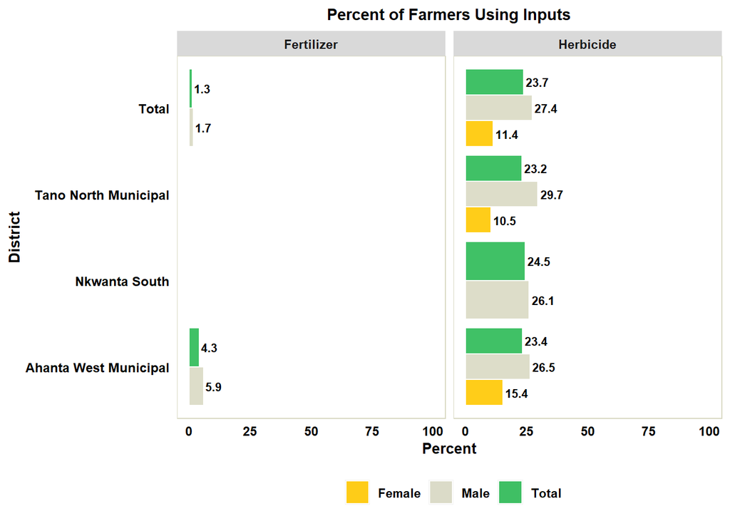

## 4.5 Input Costs

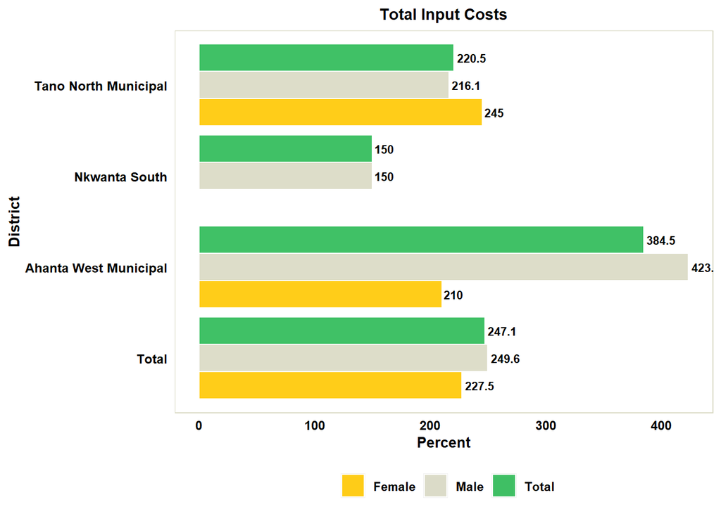

# 5 Harvests and Yield

## 5.1 Farm Yields

The harvest and subsequent farm yields are presented in the graph below.

Outputs and Yield.

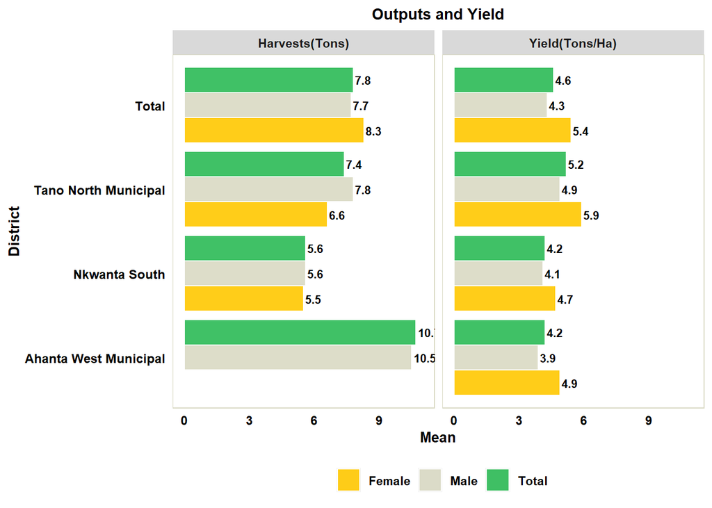

Farmers use a combination of labour for harvests. The graph below shows the types of labour used for harvesting.

Labourers Used for Harvesting.

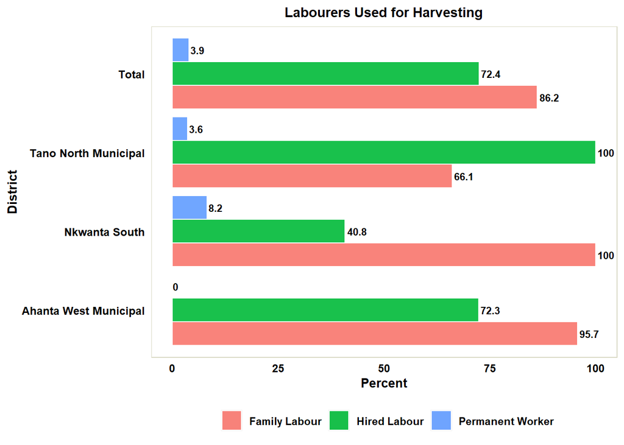

## 5.2 Harvests Costs

For those who hire labour, their cost of hired labour used for harvesting is presented below.

Harvesting Costs.

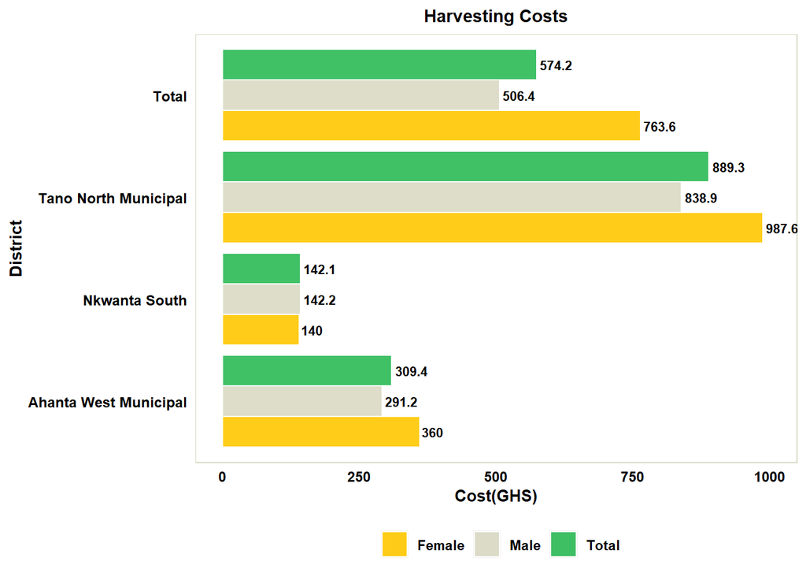

## 5.3 Use of Harvests

Sometimes the harvested FFBs are sold directly. At other times they are processed into CPO before selling. Some farmers do both at different times. The graph below presents the number of times farmers have either sold ffb direcly, processed or done both.

Use of FFB.

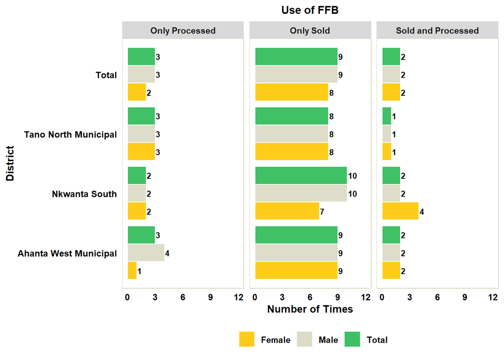

## 5.4 Palm oil per hectare - Based on farmers’ output

Palm oil per hectare is estimated under the assumption that all ffb from the farms are processed - 80% to artisanal mills (11% efficiency rate) and 20% to industrial mills (20% efficiency rate)

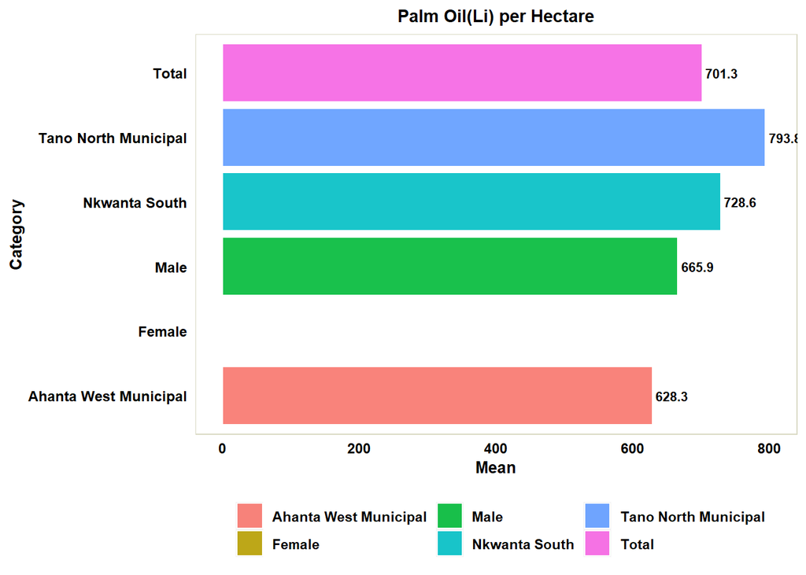

## 5.5 Palm oil per hectare - Based on farmers’ use of ffb

For farmers who use process their ffb, the palm oil produced per hectare is estimated. assuming 1 gallon is 22.5 litres(25) and 1 pigfeet is 56.25 litres(75). Use 11% extraction rate

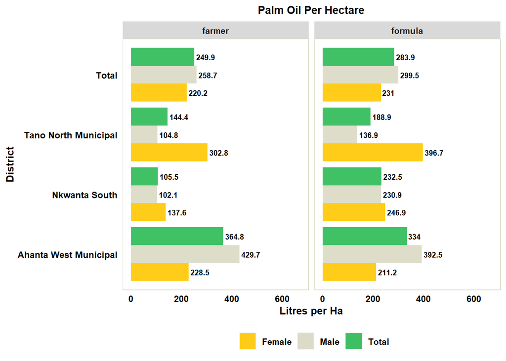

# 6 Farm Gross Margins

## 6.1 Farm Costs

The total farm costs including labour for BMP implementation, harvests and application of inputs as well as costs of inputs is estimated and presented in the graph below

Average Farm Costs.

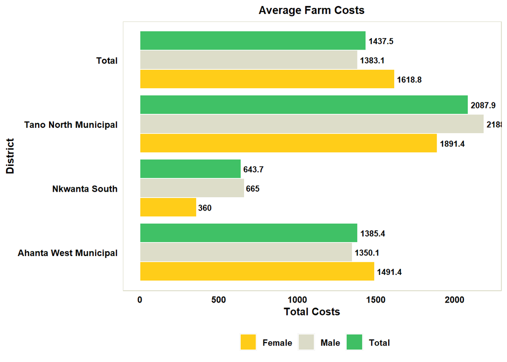

Average Farm Costs per Hectare.

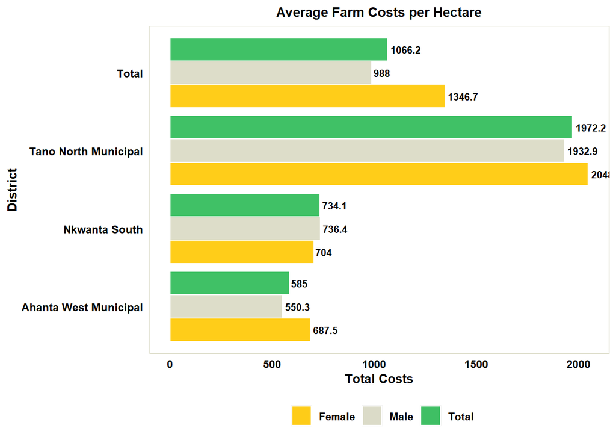

## 6.2 Farm Sales

The FFB sales, CPO sales and Total sales over the monitoring period are presented in the graph

Farm Sales.

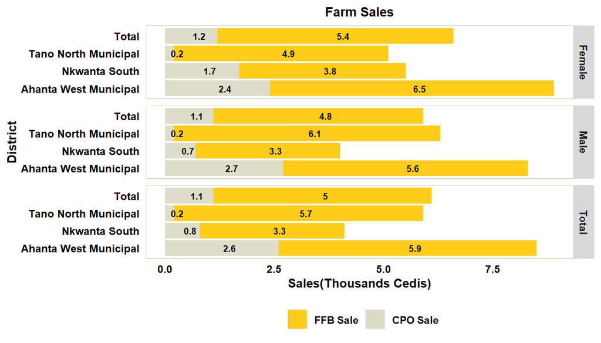

Farm Sales per Hectare.

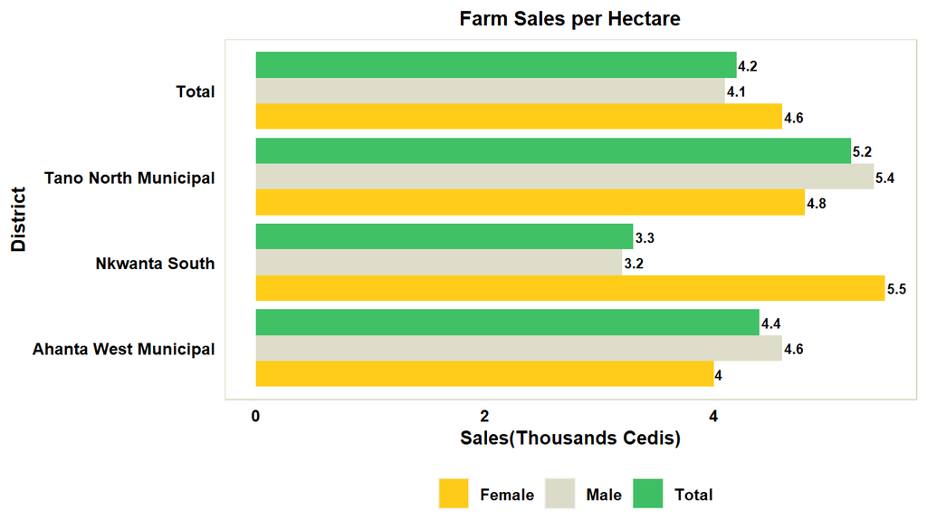

## 6.3 Gross Margins - ROUGH ESTIMATE

Gross margin is estimated as the revenue less the variable costs. For this data, variable costs are labour costs and input costs as estimated above. It is worth noting that while some farmers process their ffbs from the farm, the total costs from harvests to processing was not captured in this data. A study from FAO in 2013 estimates an average of GH90 to process 1 Tone of palm kernel. This figure is adjusted with inflation using average CPIs in 2013(111.6) and in 2022(155.28) and estimated as 125.23.

The estimated average gross margins are shown in the graph below

Gross Margins.

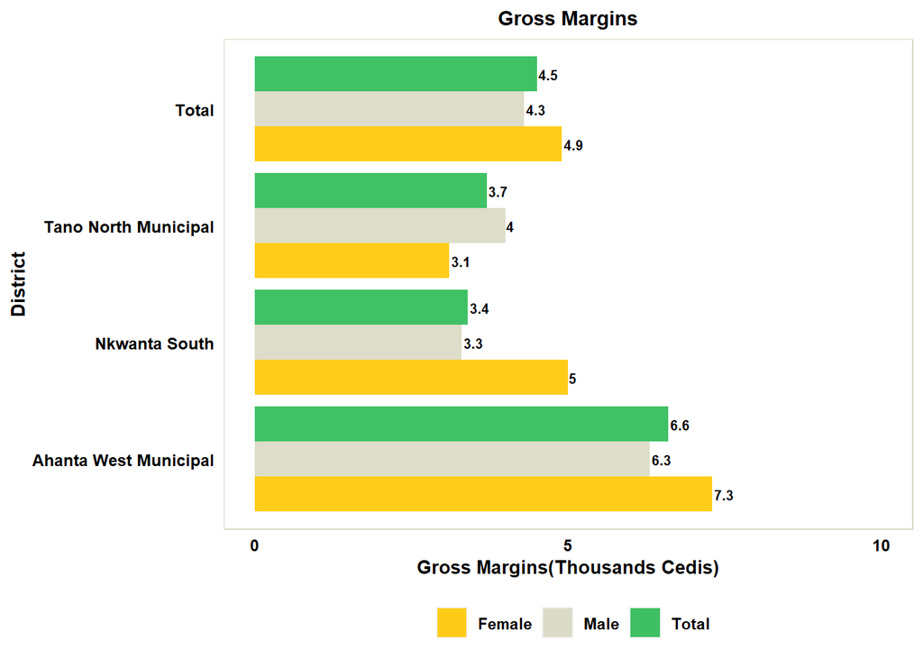

# 7 Diversification

## 7.1 Income Sources

Farmers earn from multiple sources apart from oil palm production.

Income Sources.

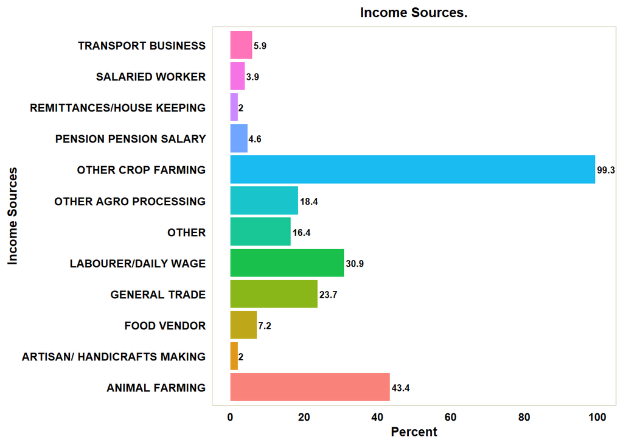

The number of income sources per farmer ranged from 1 to 6 with an average of 2.5789474. The average number of income sources for the farmers is shown below

Average Number of Income Sources.

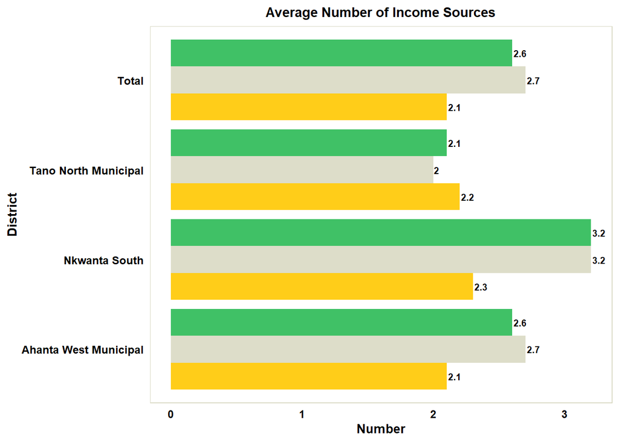